# Datenverarbeitung und -analyse

7. Oktober 2017

## magrittr - Funktionen übersichtlich kombinieren

Wenn man mehrere Funktionen kombinieren muss, um einen Datensatz aufzubereiten, kann das schnell viel Tipperei und Unübersichtlichkeit bedeuten.

```r
TrackingData <- RawTracking
TrackingData <- separate(TrackingData,
                         col = Time_Param, into = c("Time", "Parameter"),
                         sep = ":", convert = TRUE)
TrackingData <- gather(TrackingData,
                       key = "Larva", value = "Value",
                       `0`:`20`,
                       convert = TRUE)
TrackingData <- spread(TrackingData,
                       key = Parameter, value = Value,
                       convert = TRUE)
```

- Dabei hat man viel Wiederholung.
- Es ist ein Muster zu erkennen.

## Die Pipe

Das Paket `magrittr` bietet einige Funktionen, um dies zu vereinfachen.

```r
TrackingData <- RawTracking %>%
  separate(Time_Param, c("Time", "Parameter"), sep = ":", convert = TRUE) %>%
  gather("Larva", "Value", `0`:`20`, convert = TRUE) %>%
  spread(Parameter, Value, convert = TRUE)
```

> `%>%` ist eine sog. **Infix**-Funktion.

## Infix-Funktionen

Normalerweise besteht ein Funktionsaufruf aus dem Funktionsnamen gefolgt von den Argumenten in Klammern.

```r
mean(1:19, na.rm = TRUE)
```

Diese Form nennt man **Präfix**-Funktionen.

Infix-Funktionen stehen zwischen ihren Argumenten.

```r
5 + 10
```

```
## [1] 15
```

Man kann Infix-Funktionen auch als Präfix-Funktionen schreiben.

```r
`+`(5, 10)
```

```
## [1] 15
```

> Aber die Infix-Variante ist doch deutlich übersichtlicher!

## %>% und die Pipe

`%>%` nimmt das Ergebnis des linken Terms und setzt es als erstes Argument in die rechte Funktion ein.

- `x %>% f` ist gleichbedeutend mit `f(x)`.
- `x %>% f(y)` ist gleichbedeutend mit `f(x, y)`.
- `x %>% f %>% g %>% h` ist gleichbedeutend mit `h(g(f(x)))`.

## Der Platzhalter

Viele Funktionen arbeiten mit der Pipe zusammen, da das erste Argument meist der Datensatz ist. Soll der linke Term an einer anderen als der ersten Stelle eingesetzt werden, kann man dies mit `.` erreichen.

- `x %>% f(y, .)` ist gleichbedeutend mit `f(y, x)`.
- `x %>% f(y, z = .)` ist gleichbedeutend mit `f(y, z = x)`.

```r
TrackingData <- RawTracking %>%
  separate(Time_Param, c("Time", "Parameter"), sep = ":", convert = TRUE) %>%
  gather("Larva", "Value", `0`:`20`, convert = TRUE) %>%
  spread(Parameter, Value, convert = TRUE)
```

## dplyr - Wie man mit seinen Daten rechnet und sie analysiert

## Funktionen, die wir aus diesem Paket besprechen

- `mutate()` fügt einer Tabelle neue Spalten hinzu.
- `select()` reduziert eine Tabelle auf die ausgewählten Spalten.
- `rename()` benennt Variablen um.
- `filter()` entfernt Zeilen auf Grundlage ihrer Werte.
- `group_by()` und `ungroup()` gruppiert Beobachtungen aufgrund kategorischer Variablen bzw. löst die Gruppierung auf.
- `summarise()` fasst mehrere Werte zu einem zusammen. *(Im Statistik-Teil)*
- Verschiedene Funktionen, um mehrere Datensätze zusammenzufügen.

## qPCR

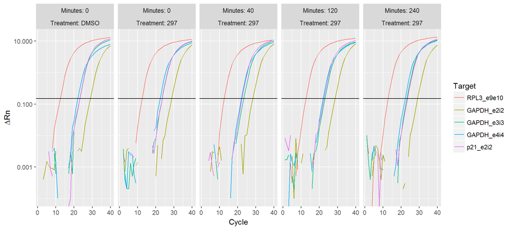

## qPCR: Die Schritte

1. Datensatz aufbereiten.
2. Jeden Wert anhand des Housekeeping-Gens korrigieren: \(\Delta Ct = Ct_{Probe} - Ct_{Housekeeping}\)
3. Unterschied zwischen dem Startwert und den verschiedenen Zeitpunkten berechnen: \(\Delta\Delta Ct = \Delta Ct_{Zeitpunkt} - \Delta Ct_{Startpunkt}\)
4. Relative Expressionsunterschiede berechnen: \(RQ = 2^{- \Delta\Delta Ct}\)
5. Das Housekeeping-Gen aus dem Datensatz rausfiltern.

## Den Datensatz einlesen

```r
qPCRA_Raw <- read_delim("../Exercises/qPCR/PlateA.csv",
                        ";", comment = "#", trim_ws = TRUE)

head(qPCRA_Raw)
```

```
## # A tibble: 6 x 26
##    Well `Sample Name` `Target Name`    Task Reporter Quencher       RQ
##   <chr>         <chr>         <chr>   <chr>    <chr>    <chr>    <dbl>
## 1    A1          0h -          CDH1 UNKNOWN     SYBR     None 1.000000
## 2    A2        0.5h -          CDH1 UNKNOWN     SYBR     None 1.631725
## 3    A3          1h -          CDH1 UNKNOWN     SYBR     None 1.579311
## 4    A4          2h -          CDH1 UNKNOWN     SYBR     None 2.949317
## 5    A5          3h -          CDH1 UNKNOWN     SYBR     None 2.698211
## 6    A6          4h -          CDH1 UNKNOWN     SYBR     None 2.867722
## # ... with 19 more variables: `RQ Min` <dbl>, `RQ Max` <dbl>, Ct <dbl>,
## #   `Ct Mean` <dbl>, `C? SD` <dbl>, `?C?` <chr>, `?C? Mean` <dbl>, `?C?
## #   SE` <dbl>, `HK Control ?C? Mean` <chr>, `HK Control ?C? SE` <chr>,
## #   `??C?` <dbl>, `Automatic Ct Threshold` <chr>, `Ct Threshold` <dbl>,
## #   `Automatic Baseline` <chr>, `Baseline Start` <int>, `Baseline
## #   End` <int>, Efficiency <int>, Comments <chr>, NOISE <chr>
```

## Die relevanten Spalten auswählen - select()

Wir benötigen die ersten drei Spalten sowie *Ct*.

```r
qPCRA <- qPCRA_Raw %>%
  select(1:3, Ct)

head(qPCRA)
```

```
## # A tibble: 6 x 4
##    Well `Sample Name` `Target Name`       Ct
##   <chr>         <chr>         <chr>    <dbl>
## 1    A1          0h -          CDH1 26.28577
## 2    A2        0.5h -          CDH1 25.28917
## 3    A3          1h -          CDH1 25.00560
## 4    A4          2h -          CDH1 24.63022
## 5    A5          3h -          CDH1 24.61910
## 6    A6          4h -          CDH1 24.76295
```

## Eine Spalte umbenennen - rename()

Die Variable *Target Name* ist ungünstig, da der Name ein Leerezeichen enthält.

```r
qPCRA <- qPCRA_Raw %>%
  select(1:3, Ct) %>%
  rename(Target = `Target Name`) %>%
  separate(`Sample Name`, c("Duration", "Treatment"), sep = " ")
```

```
## Error in loadNamespace(name): there is no package called 'tidyselect'
```

```r
head(qPCRA)
```

[output not shown]

## Beobachtungen gruppieren - group_by()

Einige Berechnungen müssen gruppenweise durchgeführt werden.

```r
qPCRA <- qPCRA_Raw %>%
  select(1:3, Ct) %>%
  rename(Target = `Target Name`) %>%
  separate(`Sample Name`, c("Duration", "Treatment"), sep = " ") %>%
  group_by(Duration, Treatment)
```

```
## Error in loadNamespace(name): there is no package called 'tidyselect'
```

```r
head(qPCRA)
```

[output not shown]

## Eine neue Variable berechnen und hinzufügen - mutate()

Ausgehend von dem Ct-Wert können wir nun Berechnungen durchführen.

```r
qPCRA <- qPCRA_Raw %>%
  select(1:3, Ct) %>%
  rename(Target = `Target Name`) %>%
  separate(`Sample Name`, c("Duration", "Treatment"), sep = " ") %>%
  group_by(Duration, Treatment) %>%
  mutate(dCt = Ct - Ct[Target == "RPL3"])
```

```
## Error in loadNamespace(name): there is no package called 'tidyselect'
```

```r
head(qPCRA)
```

[output not shown]

```r
qPCRA <- qPCRA_Raw %>%
  select(1:3, Ct) %>%
  rename(Target = `Target Name`) %>%
  separate(`Sample Name`, c("Duration", "Treatment"), sep = " ") %>%
  group_by(Duration, Treatment) %>%
  mutate(dCt = Ct - Ct[Target == "RPL3"]) %>%
  group_by(Target, Treatment) %>%
  mutate(ddCt = dCt - dCt[Duration == "0h"]) %>%
  ungroup() %>%
  mutate(RQ = 2^(-ddCt))
```

```
## Error in loadNamespace(name): there is no package called 'tidyselect'
```

```r
head(qPCRA)
```

[output not shown]

```r
qPCRA[qPCRA$Target == "RPL3", ]
```

[output not shown]

## Beobachtungen entfernen - filter()

RPL3 ist das Housekeeping-Gen. Es sollte daher zum Schluss herausgefiltert werden.

```r
qPCRA <- qPCRA_Raw %>%
  select(1:3, Ct) %>%
  rename(Target = `Target Name`) %>%
  separate(`Sample Name`, c("Duration", "Treatment"), sep = " ") %>%
  group_by(Duration, Treatment) %>%
  mutate(dCt = Ct - Ct[Target == "RPL3"]) %>%
  group_by(Target, Treatment) %>%
  mutate(ddCt = dCt - dCt[Duration == "0h"]) %>%
  ungroup() %>%
  mutate(RQ = 2^(-ddCt)) %>%
  dplyr::filter(Target != "RPL3")
```

```
## Error in loadNamespace(name): there is no package called 'tidyselect'
```

```r
head(qPCRA)
```

[output not shown]

NEVER EVER bearbeiten wir jede Datei einzeln per Hand!

## purrr - Eine Funktion auf jedes Element eines Vektors oder einer Liste anwenden

## Die Idee

Wir lesen jede Datei als Teil einer Liste ein und fügen anschließend die Datensätze zusammen.

1. Eine Liste mit allen relevanten Dateinamen erstellen.
2. Über die bekannte Funktion jede dieser Dateien einlesen.
3. Die Datensätze zu einem Datensatz zusammenfügen.
4. Den Datensatz wie zuvor bearbeiten.

## Die Dateinamen auflisten

```r
qPCR <- list.files("../Exercises/qPCR/")

str(qPCR)
```

```
##  chr [1:9] "Amplification_1.csv" "Amplification_2.csv" "Heatmaps.html" ...
```

```r
qPCR <- list.files("../Exercises/qPCR/", pattern = "^[Plate]")

qPCR
```

```
## [1] "PlateA.csv" "PlateB.csv" "PlateC.csv"
```

Mehr zu regulären Ausdrücken unter http://stringr.tidyverse.org/articles/regular-expressions.html.

`map_chr()` nimmt einen Character-Vektor, wendet auf jedes Element eine Funktion an und gibt einen Character-Vektor zurück.

```r
qPCR <- list.files("../Exercises/qPCR/", pattern = "^[Plate]") %>%
  map_chr(~ paste("../Exercises/qPCR/", .x, sep = ""))

qPCR
```

```
## [1] "../Exercises/qPCR/PlateA.csv" "../Exercises/qPCR/PlateB.csv"
## [3] "../Exercises/qPCR/PlateC.csv"
```

## Jede Datei einlesen

`map()` nimmt einen Vektor und eine Funktion. Die Funktion wird auf jedes Vektor-Element angewandt. Zurück kommt eine Liste mit dem Ergebnis.

```r
qPCR <- list.files("../Exercises/qPCR/", pattern = "^[Plate]") %>%
  map_chr(~ paste("../Exercises/qPCR/", .x, sep = "")) %>%
  map(~ read_delim(.x, ";", comment = "#", trim_ws = TRUE))

str(qPCR)
```

```
## List of 3
##  $ :Classes 'tbl_df', 'tbl' and 'data.frame':    96 obs. of  26 variables:
##   ..$ Well                  : chr [1:96] "A1" "A2" "A3" "A4" ...
##   ..$ Sample Name           : chr [1:96] "0h -" "0.5h -" "1h -" "2h -" ...
##   ..$ Target Name           : chr [1:96] "CDH1" "CDH1" "CDH1" "CDH1" ...
##   ..$ Task                  : chr [1:96] "UNKNOWN" "UNKNOWN" "UNKNOWN" "UNKNOWN" ...
##   ..$ Reporter              : chr [1:96] "SYBR" "SYBR" "SYBR" "SYBR" ...
##   ..$ Quencher              : chr [1:96] "None" "None" "None" "None" ...
##   ..$ RQ                    : num [1:96] 1 1.63 1.58 2.95 2.7 ...
##   ..$ RQ Min                : num [1:96] 0.948 NA NA NA NA ...
##   ..$ RQ Max                : num [1:96] 1.05 NA NA NA NA ...
##   ..$ Ct                    : num [1:96] 26.3 25.3 25 24.6 24.6 ...
##   ..$ Ct Mean               : num [1:96] 26.3 25.3 25 24.6 24.6 ...
##   ..$ C? SD                 : num [1:96] 0.0199 NA NA NA NA ...
##   ..$ ?C?                   : chr [1:96] NA NA NA NA ...
##   ..$ ?C? Mean              : num [1:96] 10.99 10.28 10.33 9.43 9.56 ...
##   ..$ ?C? SE                : num [1:96] 0.0179 NA NA NA NA ...
##   ..$ HK Control ?C? Mean   : chr [1:96] NA NA NA NA ...
##   ..$ HK Control ?C? SE     : chr [1:96] NA NA NA NA ...
##   ..$ ??C?                  : num [1:96] 0 -0.706 -0.659 -1.56 -1.432 ...
##   ..$ Automatic Ct Threshold: chr [1:96] "WAHR" "WAHR" "WAHR" "WAHR" ...
##   ..$ Ct Threshold          : num [1:96] 0.692 0.692 0.692 0.692 0.692 ...
##   ..$ Automatic Baseline    : chr [1:96] "WAHR" "WAHR" "WAHR" "WAHR" ...
##   ..$ Baseline Start        : int [1:96] 3 3 3 3 3 3 3 3 3 3 ...
##   ..$ Baseline End          : int [1:96] 18 17 17 16 16 16 17 17 17 18 ...
##   ..$ Efficiency            : int [1:96] 1 1 1 1 1 1 1 1 1 1 ...
##   ..$ Comments              : chr [1:96] NA NA NA NA ...
##   ..$ NOISE                 : chr [1:96] "N" "N" "N" "N" ...
##   ..- attr(*, "spec")=List of 2
##   .. ..$ cols   :List of 26
##   .. .. ..$ Well                  : list()
##   .. .. .. ..- attr(*, "class")= chr [1:2] "collector_character" "collector"
##   .. .. ..$ Sample Name           : list()
##   .. .. .. ..- attr(*, "class")= chr [1:2] "collector_character" "collector"
##   .. .. ..$ Target Name           : list()
##   .. .. .. ..- attr(*, "class")= chr [1:2] "collector_character" "collector"
##   .. .. ..$ Task                  : list()
##   .. .. .. ..- attr(*, "class")= chr [1:2] "collector_character" "collector"
##   .. .. ..$ Reporter              : list()
##   .. .. .. ..- attr(*, "class")= chr [1:2] "collector_character" "collector"
```

[output cut: 195 more lines]

```
##   .. .. ..$ Ct Threshold          : list()
##   .. .. .. ..- attr(*, "class")= chr [1:2] "collector_double" "collector"
##   .. .. ..$ Automatic Baseline    : list()
##   .. .. .. ..- attr(*, "class")= chr [1:2] "collector_character" "collector"
##   .. .. ..$ Baseline Start        : list()
##   .. .. .. ..- attr(*, "class")= chr [1:2] "collector_integer" "collector"
##   .. .. ..$ Baseline End          : list()
##   .. .. .. ..- attr(*, "class")= chr [1:2] "collector_integer" "collector"
##   .. .. ..$ Efficiency            : list()
##   .. .. .. ..- attr(*, "class")= chr [1:2] "collector_integer" "collector"
##   .. .. ..$ Comments              : list()
##   .. .. .. ..- attr(*, "class")= chr [1:2] "collector_character" "collector"
##   .. ..$ default: list()
##   .. .. ..- attr(*, "class")= chr [1:2] "collector_guess" "collector"
##   .. ..- attr(*, "class")= chr "col_spec"
```

## Die Datensätze zusammenfügen

Mit der Funktion `bind_rows()` aus `dplyr` kann man Datensätze zeilenweise zusammenfügen.

```r
qPCR <- list.files("../Exercises/qPCR/", pattern = "^[Plate]") %>%
  map_chr(~ paste("../Exercises/qPCR/", .x, sep = "")) %>%
  map(~ read_delim(.x, ";", comment = "#", trim_ws = TRUE)) %>%
  bind_rows()

head(qPCR)
```

```
## # A tibble: 6 x 28
##    Well `Sample Name` `Target Name`    Task Reporter Quencher       RQ
##   <chr>         <chr>         <chr>   <chr>    <chr>    <chr>    <dbl>
## 1    A1          0h -          CDH1 UNKNOWN     SYBR     None 1.000000
## 2    A2        0.5h -          CDH1 UNKNOWN     SYBR     None 1.631725
## 3    A3          1h -          CDH1 UNKNOWN     SYBR     None 1.579311
## 4    A4          2h -          CDH1 UNKNOWN     SYBR     None 2.949317
## 5    A5          3h -          CDH1 UNKNOWN     SYBR     None 2.698211
## 6    A6          4h -          CDH1 UNKNOWN     SYBR     None 2.867722
## # ... with 21 more variables: `RQ Min` <dbl>, `RQ Max` <dbl>, Ct <dbl>,
## #   `Ct Mean` <dbl>, `C? SD` <dbl>, `?C?` <chr>, `?C? Mean` <dbl>, `?C?
## #   SE` <dbl>, `HK Control ?C? Mean` <chr>, `HK Control ?C? SE` <chr>,
## #   `??C?` <dbl>, `Automatic Ct Threshold` <chr>, `Ct Threshold` <dbl>,
## #   `Automatic Baseline` <chr>, `Baseline Start` <int>, `Baseline
## #   End` <int>, Efficiency <int>, Comments <chr>, NOISE <chr>, `Ct
## #   SD` <dbl>, dCt <chr>
```

Und nun kann man weitermachen wie zuvor.

## Weitere Anwendungen

Eine Funktion auf jedes Element einer Liste oder eines Vektors anzuwenden hat viele nützliche Anwendungen, dir wir aus Zeitgründen leider nicht besprechen können.